# Final Project Report

2023-05-03

## Final Project Report - Data Analysis of March Madness

### Group Members

- Sid Ganesh
- Mason Langer
- Lauren Graham
- Richard Wolff

### Setup Details

- This project use the following scripts, assumed to be in your course scripts directory.
  - `COURSE/scripts/viridis.R`
  - `COURSE/scripts/ggprob.R`
- You also need the following data sets, which were submitted along side this file
  - `COURSE/data/ncaa_tournament_full.csv`
  - `COURSE/data/low_seeds.csv`
  - `COURSE/data/high_seeds.csv`

## Introduction

Basketball is an incredibly variable sport. While all sports share a degree of randomness, basketball–specifically college basketball’s “March Madness,” the single-elimination Division 1 NCAA (National Collegiate Athletics Association) National Tournament–can be truly unpredictable. Displayed by its wild upsets, incredible buzzer beaters, and “Cinderella stories”—the unexpected runs of low, underrated teams far into the tournament—March Madness provides a unique glimpse into basketball odds and probabilities. As a group, we chose the NCAA D1 Men’s National Tournament as both our topic and our sample, as we wanted to see the statistical trends in common with the most successful of the tournament teams over the past decade. Specifically, we wanted to see how a team’s statistical ratings before the tournament would affect their success in the tournament field. **As such, we believe teams with highly proficient statistical profiles, which include offensive and defensive efficiency, tend to be ranked higher (according to their seed) than their low-seed counterparts.**

## Background

The majority of our data used throughout the report was gathered from [**kenpom.com**](https://www.kenpom.com), a renowned basketball analytics website that tracks statistics for all 358 teams in NCAA Division 1 Men’s Basketball. Using data summaries for every year between 2012 and 2023 (excluding 2020 due to COVID-19), we were able to compile a data set with the following variables[^1]:

- *Season*: year of the tournament
- *Offensive Efficiency (OE)*: points scored per game
  - *Adjusted Off. Efficiency (AdjOE)*: points scored per 100 possessions
  - A higher offensive efficiency means that the team has a good offensive
- *Defensive Efficiency (DE)*: points allowed per game
  - *Adjusted Def. Efficiency (AdjDE)*: points allowed per 100 possessions
  - A lower defensive efficiency means that the team has a good defense
- *Efficiency Margin (EM)*: difference of offensive efficiency and defensive efficiency ($OE - DE$)
  - *Adjusted Eff. Margin (AdjEM)*: difference of adjusted off. efficiency and adjusted def. efficiency
- *Seed*: seed of the team in the tournament occurring in that respective season

Each data value is that team’s value **before** the national tournament. Our data analysis will prioritize *AdjOE*, *AdjDE*, and *AdjEM*, as they represent a standardized metric that can be used to effectively compare teams; additionally, we will look at a team’s seed in a given year’s tournament, labelled *seed_season* in the dataset. However, as there are many different qualitative and quantitative factors that can affect a single basketball game, it is not possible to get the full picture of a basketball team using three advanced statistics. Although it may not showcase the full picture, our three primary metrics can be used to provide a strong explanation for a team’s prolonged success. Moving forward, we will use *AdjOE*, *AdjDE*, and *AdjEM* to distinguish between successful and unsuccessful basketball programs, and the typical profile of a championship-contending team.

## Analysis

#### Adjusted Offensive and Defensive Ratings

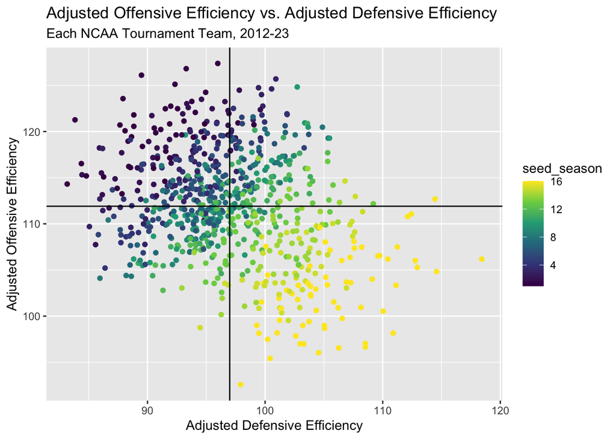

```r
ggplot(ncaa_full, aes(x = AdjDE, y = AdjOE, color = seed_season), size = 3) +
  geom_point() +
  geom_hline(yintercept = mean(ncaa_full$AdjOE)) +
  geom_vline(xintercept = mean(ncaa_full$AdjDE)) +
  xlab("Adjusted Defensive Efficiency") +
  ylab("Adjusted Offensive Efficiency") +
  ggtitle("Adjusted Offensive Efficiency vs. Adjusted Defensive Efficiency", subtitle="Each NCAA Tournament Team, 2012-23")
```

### Confidence Intervals for High-Seeded and Low-Seeded Teams

#### Comparing Adjusted Offensive and Defensive Efficiencies By Seed

#### Visualizing Differences in Distribution by Seeding Group

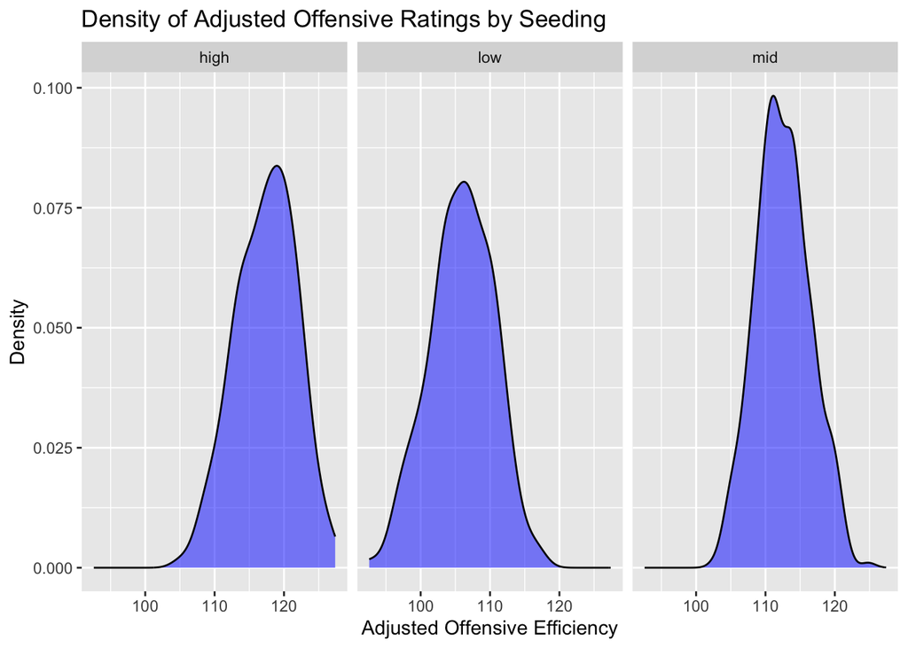

```r
ggplot(ncaa_full, aes(x = AdjOE)) +
  geom_density(fill = 'blue', alpha = 0.5) +
  facet_wrap(vars(seeding)) +
  xlab("Adjusted Offensive Efficiency") +
  ylab("Density") +
  ggtitle("Density of Adjusted Offensive Ratings by Seeding")
```

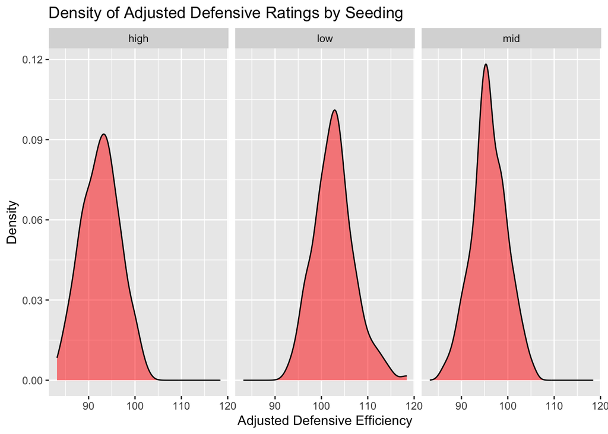

```r
ggplot(ncaa_full, aes(x = AdjDE)) +
  geom_density(fill = 'red', alpha = 0.5) +
  facet_wrap(vars(seeding)) +
  xlab("Adjusted Defensive Efficiency") +
  ylab("Density") +
  ggtitle("Density of Adjusted Defensive Ratings by Seeding")
```

- These three graphs are roughly the opposite of what was seen in the adjusted offensive efficiency distribution, which is not surprising. Instead, the right-skew of the distribution for high seeds suggests that these teams typically have great defenses, hence their low adjusted defensive efficiency.
  - Again, the opposite is shown for low seeds, which is less polarized than what was seen with offensive efficiency, but still shows a clear pattern of lower-seeded teams having worse defenses than their competition.

#### Calculating Confidence Intervals for Means of Adjusted Efficiency Ratings

- Adjusted offensive and defensive efficiency for high-seeded teams

```r
hi_adj_oe = high %>%
  pull(AdjOE)

hi_adj_de = high %>%
  pull(AdjDE)

xbar_hi_oe = mean(hi_adj_oe)
sigma_hi_oe = sd(hi_adj_oe)
se_hi_oe = sigma_hi_oe / sqrt(length(hi_adj_oe))

ci_hi_oe = xbar_hi_oe + c(-1, 1)*1.96*se_hi_oe
ci_hi_oe
```

```
## [1] 116.7338 118.0203
```

```r
xbar_hi_de = mean(hi_adj_de)
sigma_hi_de = sd(hi_adj_de)
se_hi_de = sigma_hi_de / sqrt(length(hi_adj_de))

ci_hi_de = xbar_hi_de + c(-1, 1)*1.96*se_hi_de
ci_hi_de
```

```
## [1] 91.99374 93.18933
```

> We are 95% confident that the true mean for a high-seeded team’s adjusted offensive efficiency is between 116.73 and 118.02, while the true mean for their adjusted defensive efficiency is between 91.99 and 93.19.
- …for lower-seeded teams

```r
low_adj_oe = low %>%
  pull(AdjOE)

low_adj_de = low %>%
  pull(AdjDE)


xbar_low_oe = mean(low_adj_oe)
sigma_low_oe = sd(low_adj_oe)
se_low_oe = sigma_low_oe / sqrt(length(low_adj_oe))

ci_low_oe = xbar_low_oe + c(-1, 1)*1.96*se_low_oe
ci_low_oe
```

```
## [1] 105.2830 106.5501
```

```r
xbar_low_de = mean(low_adj_de)
sigma_low_de = sd(low_adj_de)
se_low_de = sigma_low_de / sqrt(length(low_adj_de))

ci_low_de = xbar_low_de + c(-1, 1)*1.96*se_low_de
ci_low_de
```

```
## [1] 102.1172 103.3165
```

> We are 95% confident that the true mean for a low-seeded team’s adjusted offensive efficiency is between 105.28 and 106.55, while the true mean for their adjusted defensive efficiency is between 102.12 and 103.32.

### Regression with Adjusted Efficiency Margin and Seeds

1. Determining correlation coefficient

```r
ncaa_adj_em = ncaa_full %>%
  pull(AdjEM)

seeds = ncaa_full %>%
  pull(seed_season)

r = cor(ncaa_adj_em, seeds)
r
```

```
## [1] -0.8997014
```

- $r=-0.8997$ suggests that the data points are tightly clustered around a negative slope
2. Regression Hypothesis Testing
- $H_0$ : $\beta_1=0$ (there is no association between Adjusted Efficiency Margin and Seeding)
- $H_a$ : $\beta_1\neq0$ (there is a linear association between Adjusted Efficiency Margin and Seeding)

```r
lm_ncaa = lm(seed_season ~ AdjEM, data = ncaa_full)

summary(lm_ncaa) %>%
  print()
```

```
##
## Call:
## lm(formula = seed_season ~ AdjEM, data = ncaa_full)
##
## Residuals:
##     Min      1Q  Median      3Q     Max
## -5.6909 -1.3747 -0.0711  1.4622  6.5509
##
## Coefficients:
##              Estimate Std. Error t value Pr(>|t|)
## (Intercept) 15.756163   0.144292   109.2   <2e-16 ***
## AdjEM       -0.465962   0.008277   -56.3   <2e-16 ***
## ---
## Signif. codes:  0 '***' 0.001 '**' 0.01 '*' 0.05 '.' 0.1 ' ' 1
##
## Residual standard error: 2.042 on 746 degrees of freedom
## Multiple R-squared:  0.8095, Adjusted R-squared:  0.8092
## F-statistic:  3169 on 1 and 746 DF,  p-value: < 2.2e-16
```

> From the given summary, we can see that $\beta_0=15.756$, the intercept of the regression line, and $\beta_1=-0.466$, the slope of the regression line. Furthermore, we observe a p-value of $2.2*10^{-16}$, with which we can reject the null hypothesis that there is no association between Adjusted Efficiency Margin and Seeding, at an alpha level of 0.05. This is statistically significant evidence that there indeed is a strong linear association between Adjusted Efficiency Margin and Seeding, as can be observed in the below graph.
3. Residual Plot

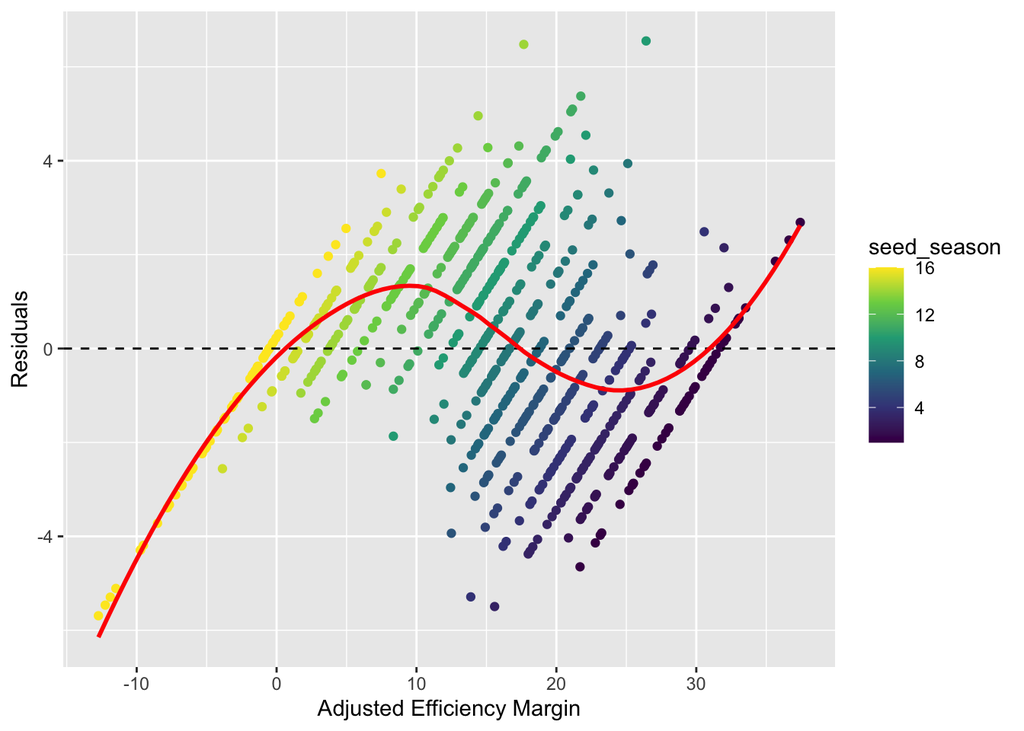

```r
ncaa_resid = ncaa_full %>%
  mutate()
ncaa_resid$resid = lm_ncaa$residuals
ggplot(ncaa_resid, aes(x=AdjEM, y=resid, color=seed_season)) +
  geom_point() +
  geom_hline(yintercept=0, linetype="dashed", color="black") +
  geom_smooth(se=F, color="red") +
  xlab("Adjusted Efficiency Margin") +
  ylab("Residuals")
```

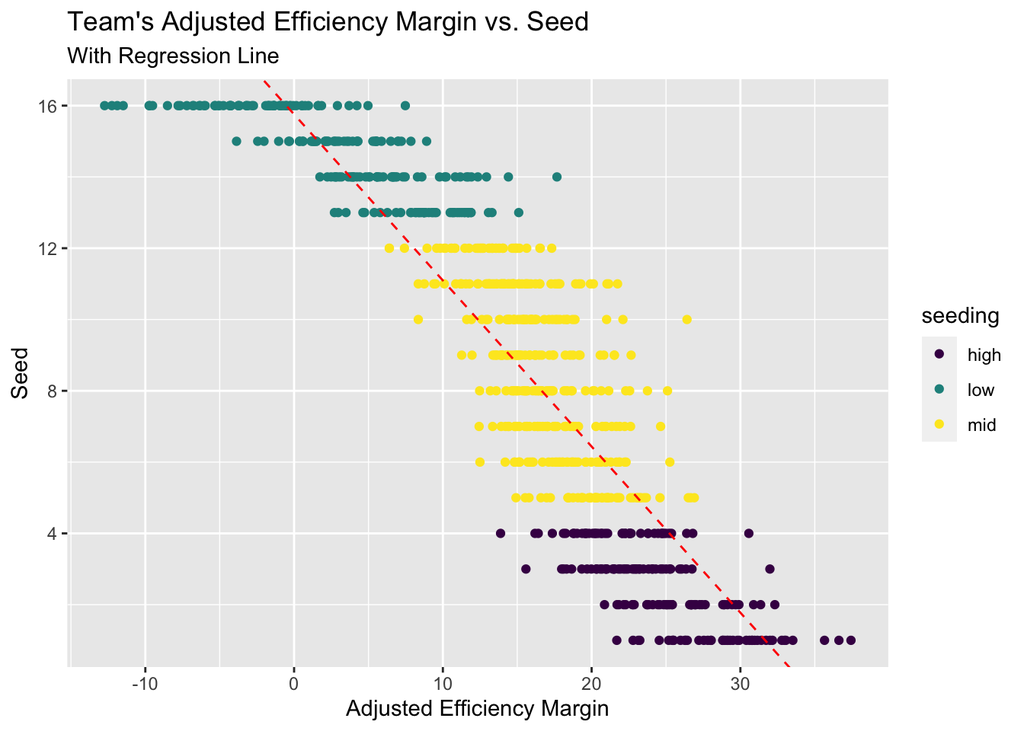

```r
ggplot(ncaa_full, aes(x = AdjEM, y = seed_season, color = seeding)) +
  geom_point() +
  geom_abline(slope = -0.466, intercept = 15.756, color = 'red', linetype='dashed') +
  xlab("Adjusted Efficiency Margin") +
  ylab("Seed") +
  ggtitle("Team's Adjusted Efficiency Margin vs. Seed", subtitle="With Regression Line")
```

#### Visualizing Average Adjusted EM by Seed to Verify Regression Findings

```r
ncaa_seed_sum = ncaa_full %>%
  group_by(seed_season) %>%
  summarize(avg_adj_oe = round(mean(AdjOE), 2),
            avg_adj_de = round(mean(AdjDE), 2),
            avg_adj_em = round(mean(AdjEM), 2))

ncaa_seed_sum %>%
  print(n = Inf)
```

```
## # A tibble: 16 × 4
##    seed_season avg_adj_oe avg_adj_de avg_adj_em
##          <dbl>      <dbl>      <dbl>      <dbl>
##  1           1       120.       90.8      29.0
##  2           2       118.       92.4      26.0
##  3           3       116.       93.7      22.4
##  4           4       115.       93.5      21.6
##  5           5       114.       93.7      20.7
##  6           6       113.       94.9      18.5
##  7           7       113.       95.9      17.6
##  8           8       113.       95.5      17.2
##  9           9       111.       95.4      16.1
## 10          10       113.       96.8      16.0
## 11          11       112.       97.4      14.7
## 12          12       110.       97.7      12.6
## 13          13       109.       99.9       9.08
## 14          14       108.      101.        6.87
## 15          15       106.      103.        2.87
## 16          16       103.      106.       -3.09
```

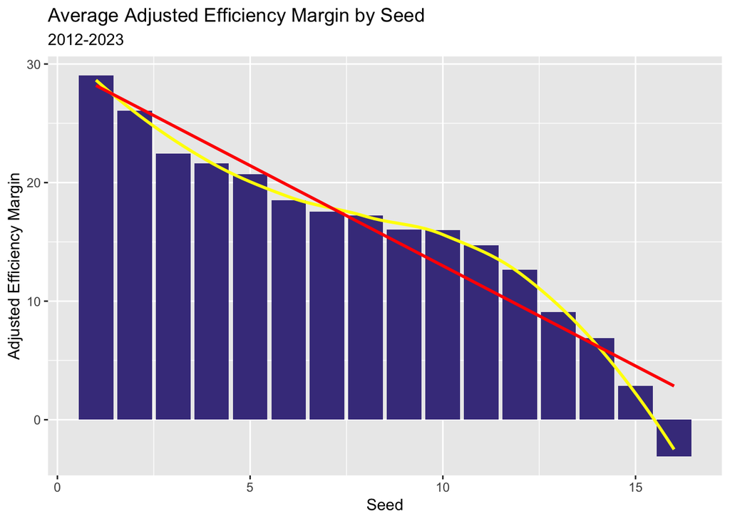

```r
ggplot(ncaa_seed_sum, aes(x = seed_season, y = avg_adj_em)) +
  geom_col(fill = 'slateblue4') +
  geom_smooth(se = FALSE, color = 'yellow') +
  geom_smooth(se = FALSE, color = 'red', method = 'lm') +
  xlab("Seed") +
  ylab("Adjusted Efficiency Margin") +
  ggtitle("Average Adjusted Efficiency Margin by Seed",
          subtitle="2012-2023 ")
```

> Higher seeds, specifically 1-4 seeds, have great efficiency margins ($>20$+), while low seeds (13-16) have significantly low efficiency margins, with the average 16 seed having a negative efficiency margin.
- Negative efficiency margins mean that the team has, on average, been outscored by their opponents ($AdjDE > AdjOE$)

> Similar to our findings in the regression model, the bar graph above shows a roughly linear relationship between seeding and adjusted efficiency margin, leading us to further believe our previous findings.

### Top Four Teams (since 2012) in Adjusted Offensive and Adjusted Defensive Efficiency

#### Offensive Efficiency

```r
top4_aoe = ncaa_full %>%
  mutate(AdjOE = round(AdjOE, 2)) %>%
  slice_max(order_by = AdjOE, n = 4) %>%
  select(Season, TeamName, AdjOE, seed_season)

top4_aoe %>%
  print.data.frame(digits = 5)
```

```
##   Season  TeamName  AdjOE seed_season
## 1   2018 Villanova 127.38           1
## 2   2015 Wisconsin 126.82           1
## 3   2021   Gonzaga 126.11           1
## 4   2014 Creighton 125.70           3
```

> The top four highest adjusted offensive efficiencies since 2012 include **2018 Villanova**, **2015 Wisconsin**, **2021** **Gonzaga**, and **2014 Creighton**. The sample features three one seeds, all of which made the National Championship game.

#### Defensive Efficiency

```r
top4_ade = ncaa_full %>%
  mutate(AdjDE = round(AdjDE, 2)) %>%
  slice_min(order_by = AdjDE, n = 4) %>%
  select(Season, TeamName, AdjOE, seed_season)

top4_ade %>%
  print.data.frame(digits = 5)
```

```
##   Season   TeamName  AdjOE seed_season
## 1   2013 Louisville 114.31           1
## 2   2015   Kentucky 121.27           1
## 3   2018   Virginia 116.53           1
## 4   2015   Virginia 115.32           2
```

> The top four highest adjusted defensive efficiencies since 2012 include **2013 Louisville**, **2015 Kentucky**, **2018** and **2015** **Virginia**. The sample features three one seeds, two of which made it the Final Four–Louisville being the 2013 National Champion.

## Discussion

> To restate our thesis, we believe that teams with highly proficient statistical profiles, including high offensive and low defensive ratings, are typically seeded higher than teams with average or below average statistical profiles. As can be seen in our brief data analysis above, out of the all the teams from the past 10 years (not including 2020 due to the pandemic), average efficiency margin is highest with higher seeds and lowest (even negative) with lower seeds. Furthermore, just doing a brief survey of the top 4 teams in regards to their defensive and offensive ratings in the whole data set, they all appear to be be 3 seed or lower, and, interestingly, almost always make it into the Final Four and the Championship game. Finally, teams with a combination of a low defensive efficiency and a high offensive efficiency are concentrated with seedings of 1-4. All of our graphs provide strong evidence in proving our thesis that higher-seeded teams are statistically greater than those of lower-seeded teams.

> Of course, we must consider the short-comings of our data analysis. There are many lower seeded teams who make it far in the tournament and have offensive and defensive efficiency ratings that are not dissimilar to the majority of the higher seeded teams. These “Cinderella” story teams surface every year and are generally unpredictable in how far they will go in the tournament. Furthermore, these teams can create many upsets in the tournament. A prime example is 16-seed Fairleigh Dickinson beating 1-seed Purdue in this year’s tournament. Naturally, we must consider that these “Cinderella stories” may dissuade the strength of our findings, as higher-seeded teams may not always be the best of the best, no matter their strong statistical profiles. “Cinderella stories” demonstrate that there is far more randomness to basketball than can simply be defined in four variables

> In the future, we can consider many other extraneous variables as well. For example, continuing with the example of Fairleigh Dickinson v. Purdue, many argue that Purdue had a very easy schedule coming into the tournament, and that they were a “fraud” one seed, which is why a 16 seed was able to beat them. This in no way diminishes FDU and other lower-seeded teams, but this could help us analyze factors leading to higher-seed teams being beaten by lower seeded teams, as logic would tell us otherwise. Furthermore, we can critique higher seeded teams by evaluating the strength of their schedule leading into the tournament. In order to do this, we would have to consider new data about the pre-tournament schedules of these teams whether or not they deserved their seeding. Additional analysis could also include the correlation between the strength of a conference of a team and their seeding and performance in the tournament. Additionally, we can include the data from every tournament that has ever occurred and peform analyses per decade to see the variation of seedings affecting performance. Finally, it is important to recognize the the March Madness Tournament is essentially random in the end, and anything can happen, ranging from many factors such as injuries to off-court troubles.

> To conclude, higher-seeded (1-4) teams tend to have a greater combination of adjusted offense efficiency and defensive efficiency than lower-seed (13-16) teams. This is supported by our analysis of efficiency margins, offensive and defensive efficiency, and seeding. Some future steps include identifying key characteristics of lower-seeded teams that allow them to go further in the tournament and out-perform the statistically greater higher seeds.

## References

[^1]: [**Kenpom Ratings Glossary**](https://kenpom.com/blog/ratings-glossary/)